# Modelos_lineares

Mauricio Diaz

2024-02-10

## Modelos lineales

En este script incluyo el código para los modelos lineales entre la riqueza y la pendiente en categorías de cambio de cobertura en méxico

#### Preparación de los datos

Primero, voy a cargar los datos de las especies. Esta tabla “spd.list.join” contiene las coordenadas de los centroides de los pixeles de las especies. De manera que cada fila corresponde a cada pixel de distribución de cada una de las 56 especies

```r
# Cargar paquetes
library(letsR)
library(tidyverse)
library(sf)
library(terra)
library(ape)
library(vegan)
library(gstat)
library(lattice)
library(nlme)
library(MuMIn)
```

```r
# Cargo la tabla para optimizar tiempo
spd.list.join<- read.table("F:/Maestria_DD/Shapes_MSc_DD/outputs/tablas/spp_PAM.txt",sep="\t", dec=".", header=T)
head(spd.list.join)
```

```
##                   x        y     spp
## Ap_wood.1 -108.0125 31.69583 Ap_wood
## Ap_wood.2 -108.0208 31.67917 Ap_wood
## Ap_wood.3 -108.0208 31.67083 Ap_wood
## Ap_wood.4 -108.0125 31.65417 Ap_wood
## Ap_wood.5 -108.0042 31.65417 Ap_wood
## Ap_wood.6 -108.0042 31.64583 Ap_wood
```

Ya con la tabla de las especies voy a construir el raster de riqueza con el paquete **letsR**. LetsR me permite crear la matriz de presencia ausencia y además construye un mapa de riqueza a una resolución determinada; 10km en este caso

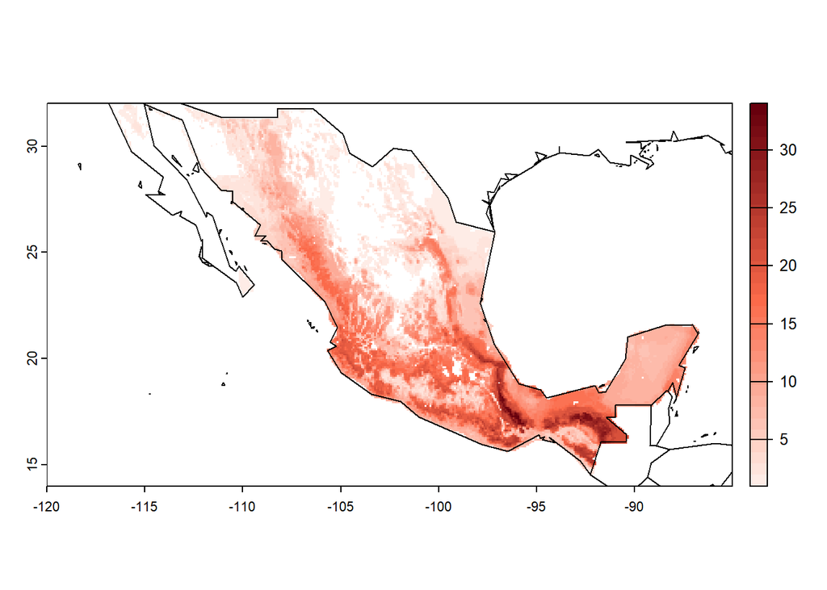

```r
#1. Hay que crear la Matriz de presencia-ausencia PAM a partir de los puntos de presencia a una resolucion de 10km

PAM<-lets.presab.points(xy= as.matrix(spd.list.join[,1:2]),
                        species= spd.list.join$spp,
                        xmn = -120,
                        xmx = -85,
                        ymn = 14,
                        ymx = 32, #10km 0.08333 / 30km 0.24999 /50km 0.41665
                        resol = 0.08333)
plot(PAM)
```

```r
summary(PAM)
```

```
##
## Class: PresenceAbsence
## _ _
## Number of species: 56
## Number of cells: 19340
## Cells with presence: 19340
## Cells without presence: 0
## Species without presence: 0
## Species with the largest range: Le_verr
## _ _
## Grid parameters
## Resolution: 0.08333, 0.08333 (x, y)
## Extention: -120, -85.0014, 14, 31.99928 (xmin, xmax, ymin, ymax)
## Coord. Ref.:  +proj=longlat +datum=WGS84 +no_defs
```

```r
#Genero un objeto raster con la riqueza
PAM.raster<-PAM$Richness_Raster
```

Ahora, lo siguiente es crear la tabla con los valores de pendiente y cobertura para cada valor de riqueza. Para eso hay que cargar los rasters de pendiente y cobertura INEGI. Los mapas estan en diferente resolución, entonces hay que remuetsrearlos

```r
# Remuestrear pendiente ---------------------------------------------------

slope<-rast("F:/Maestria_DD/Shapes_MSc_DD/WorldClim_30s/wc2.1_30s_elev/slope_mx_g_res.tif")
slope.3<-resample(slope, PAM.raster, method="bilinear")

# Remuetsrear áreas conservadas y transformadas --------------

inegivii<-rast("F:/Maestria_DD/Shapes_MSc_DD/INEGI/Cambios/INEGI_VII_TC.tif")
inegivii.3<-resample(inegivii, PAM.raster, method="near")


# 3. Extraer pendiente e inegi vii para cada pix de riqueza --------
z.slp<-terra::extract(c(slope.3,inegivii.3, PAM.raster),
               as.points(PAM.raster), xy=T) |>
  na.omit()
head(z.slp)
```

```
##    ID slope_mx_g INEGI_VII_TC lyr.1         x        y
## 40 40   2.284621            2     0 -116.7085 31.95762
## 41 41   3.498277            1     0 -116.6251 31.95762
## 42 42   5.146585            2     0 -116.5418 31.95762
## 43 43   4.051637            2     0 -116.4585 31.95762
## 44 44   2.912461            2     0 -116.3751 31.95762
## 45 45   1.348675            2     0 -116.2918 31.95762
```

```r
# Ordenar columnas
z.slp<-z.slp[,c(5,6,4,2,3)]
# Renombrar columnas
names(z.slp)<-c("x","y","z","slope","cat")
# La variable es numerica, entonces voy a crear otra columna con las letras que cada una representa y convertir esa en caracteres
z.slp$cat<-as.character(z.slp$cat)
z.slp$cat2<-z.slp$cat
z.slp[which(z.slp$cat2==2),6]<-"T"
z.slp[which(z.slp$cat2==1),6]<-"C"
# Revisar la etsructura de cada columna
str(z.slp)
```

```
## 'data.frame':    24032 obs. of  6 variables:
##  $ x    : num  -117 -117 -117 -116 -116 ...
##  $ y    : num  32 32 32 32 32 ...
##  $ z    : num  0 0 0 0 0 0 0 0 2 2 ...
##  $ slope: num  2.28 3.5 5.15 4.05 2.91 ...
##  $ cat  : chr  "2" "1" "2" "2" ...
##  $ cat2 : chr  "T" "C" "T" "T" ...
```

```r
levels(factor(z.slp$cat))
```

```
## [1] "1" "2"
```

#### Modelos lineares

Primero, voy a correr un modelo linear simple y ver los residuales

```r
aves.ras1.lm <- lm(z ~ slope:cat2, data = z.slp)
summary(aves.ras1.lm)
```

```
##
## Call:
## lm(formula = z ~ slope:cat2, data = z.slp)
##
## Residuals:
##     Min      1Q  Median      3Q     Max
## -22.704  -3.683  -1.799   3.672  22.656
##
## Coefficients:
##             Estimate Std. Error t value Pr(>|t|)
## (Intercept)  2.37327    0.05119   46.36   <2e-16 ***
## slope:cat2C  1.04908    0.01550   67.69   <2e-16 ***
## slope:cat2T  1.97661    0.01562  126.52   <2e-16 ***
## ---
## Signif. codes:  0 '***' 0.001 '**' 0.01 '*' 0.05 '.' 0.1 ' ' 1
##
## Residual standard error: 5.4 on 24029 degrees of freedom
## Multiple R-squared:  0.4076, Adjusted R-squared:  0.4075
## F-statistic:  8266 on 2 and 24029 DF,  p-value: < 2.2e-16
```

Los residuales parecen ser normales… Voy a ver

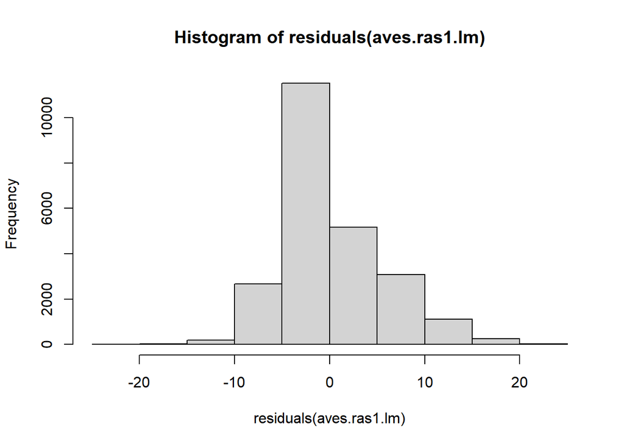

```r
residuals(aves.ras1.lm) |>
  hist()
```

Y los plots del modelo ¿como son?

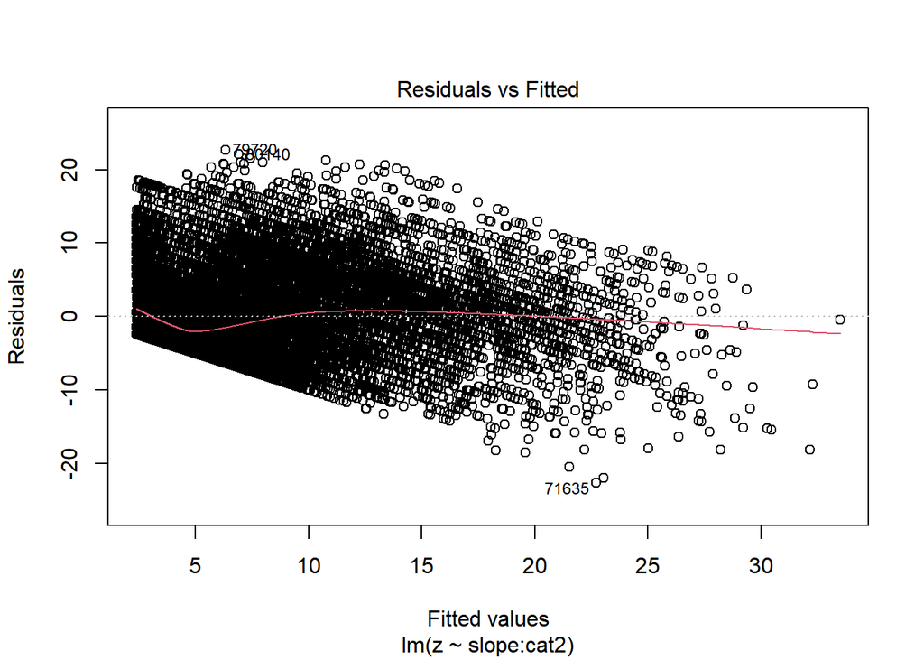

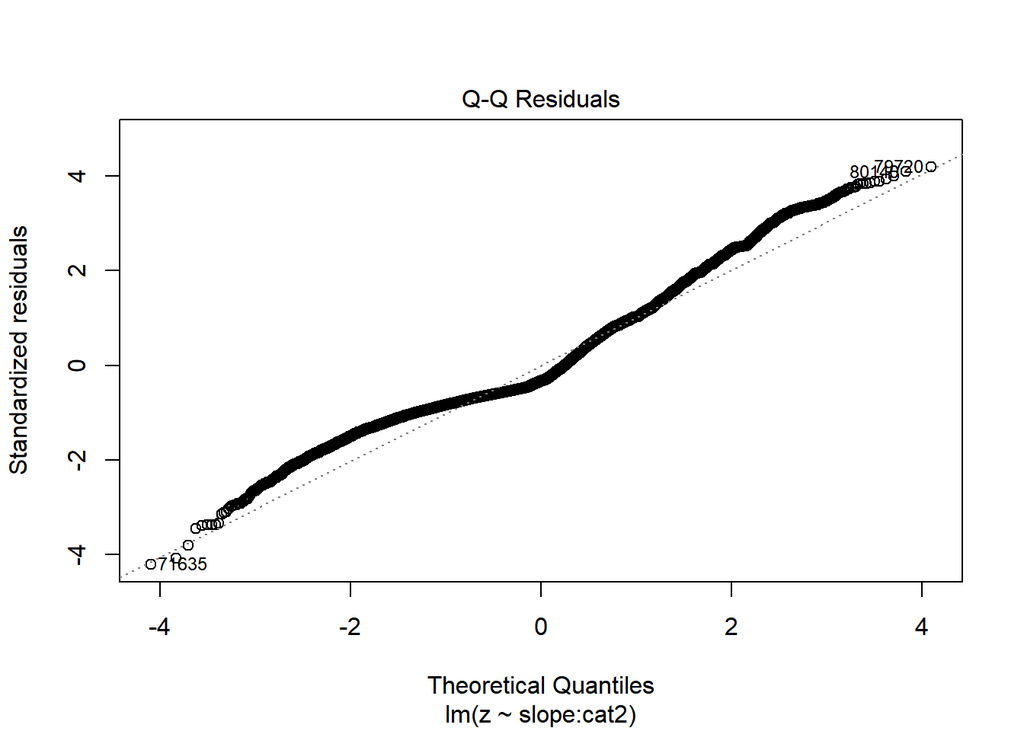

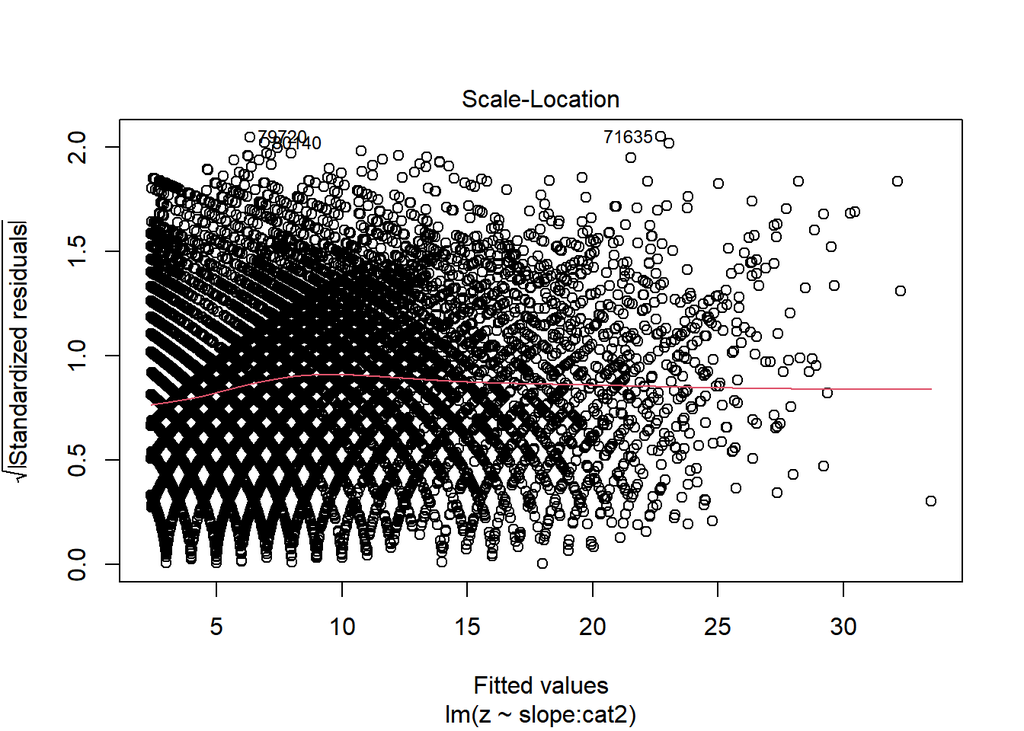

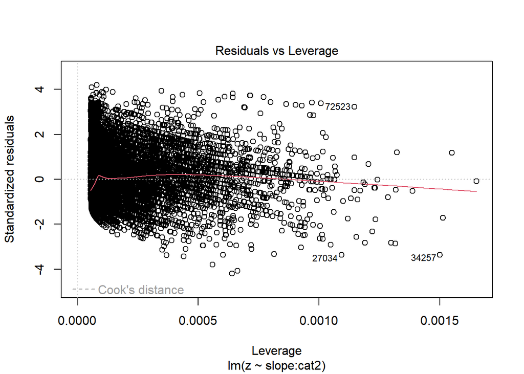

```r
plot(aves.ras1.lm)
```

#### Parece que hay normalidad en los resiudales… Pero, estará bien? O será que existe autocorrelación espacial?

voy a probar el índice de Moran

1. Con el código que me pasó el profe Juan

```r
#Moran's Test
dists <- as.matrix(dist(cbind(z.slp$x, z.slp$y))) # es importante que no existan coordenadas duplicadas! o sitios con las mismas coordenadas. Esto es una matriz de distancias cartesianas entre cada par de coordenadas que repreentan un punto en el espacio

# inverso de esa distancia
dists.inv <- 1/dists

# La diagonal de esa matriz tiene un valor de cero porque la distancia al mismo punto es cero y este objeto tiene valores de infinito
diag(dists.inv) <- 0

# Reviso
dists.inv[1:5, 1:5]
```

```
##          1        2        3        4        5
## 1  0.00000 12.00048  6.00024  4.00016  3.00012
## 2 12.00048  0.00000 12.00048  6.00024  4.00016
## 3  6.00024 12.00048  0.00000 12.00048  6.00024
## 4  4.00016  6.00024 12.00048  0.00000 12.00048
## 5  3.00012  4.00016  6.00024 12.00048  0.00000
```

```r
# Índice de Moran
moranI <- Moran.I(x=z.slp$z, weight=dists.inv) # p.value significativo indica fuerte autocorrelacion espacial
#La matriz de pesos es la distancia euclidiana que hay entre cada ímtp

moranI
```

```
## $observed
## [1] 0.3130359
##
## $expected
## [1] -4.161292e-05
##
## $sd
## [1] 0.0001033955
##
## $p.value
## [1] 0
```

## P-valor de 0! por que?

Será que si uso los datos que me pasó Juan sigue dando cero?

```r
# Datos
data <- read.csv("F:/Maestria_DD/Shapes_MSc_DD/Scripts/codigoGLS/data.csv")

# Normalized variables
# z-transform on our data (mean-centering and dividing by one standard deviation)
datos_z <- decostand(data[,c(4:7)], "standardize")
datos_z <- cbind(data[,c(1:3,8)], datos_z)
head(datos_z)
```

```
##   ID   coordx   coordy         y       x1          x2         x3         x4
## 1  1 -9.00210 31.11301 0.8131579 1.187781 -0.44920008 -0.9858963 -0.9351643
## 2  2 -9.02395 31.07034 0.3605263 1.213732 -0.57608006 -0.3026432 -0.4201463
## 3  3 -9.05787 30.93887 0.6131579 1.281902 -0.35884010 -0.9858963 -0.6776553
## 4  4 -9.14049 30.79459 0.9131579 1.369698 -0.25053012 -0.9858963 -0.6776553
## 5  5 -9.20639 30.67361 0.8763158 1.445017 -0.09559014 -0.9858963 -0.9351643
## 6  6 -9.37698 30.62168 0.4552632 1.519734  0.69859973 -0.9858963 -0.4201463
```

```r
##################################################
#Spatial correlation test
#Moran's Test
dists2 <- as.matrix(dist(cbind(datos_z$coordx, datos_z$coordy))) # es importante que no existan coordenadas duplicadas! o sitios con las mismas coordenadas. Esto es una matriz de distancias cartesianas entre cada par de coordenadas que repreentan un punto en el espacio
dists.inv2 <- 1/dists2 #inverso de esa distancia
diag(dists.inv2) <- 0 #la diagonal de esa matriz tiene un valor de cero porque la distancia al mismo punto es cero y este objeto tiene valores de infinito
dists.inv2[1:5, 1:5]
```

```
##           1         2        3        4        5
## 1  0.000000 20.859826 5.468889 2.880241 2.063691
## 2 20.859826  0.000000 7.365111 3.340400 2.290069
## 3  5.468889  7.365111 0.000000 6.014633 3.289384
## 4  2.880241  3.340400 6.014633 0.000000 7.258781
## 5  2.063691  2.290069 3.289384 7.258781 0.000000
```

```r
##
moranI2 <- Moran.I(x=datos_z$y, weight=dists.inv2) # p.value significativo indica fuerte autocorrelacion espacial
#La matriz de pesos es la distancia euclidiana que hay entre cada ímtp
moranI2
```

```
## $observed
## [1] 0.2427549
##
## $expected
## [1] -0.005291005
##
## $sd
## [1] 0.0248998
##
## $p.value
## [1] 0
```

#### También el valor-P es 0!! ¿Qué interpreta uno ahí?

2. LetsR tiene una forma de generar un índice de Moran con una grafica, vamos a probar…

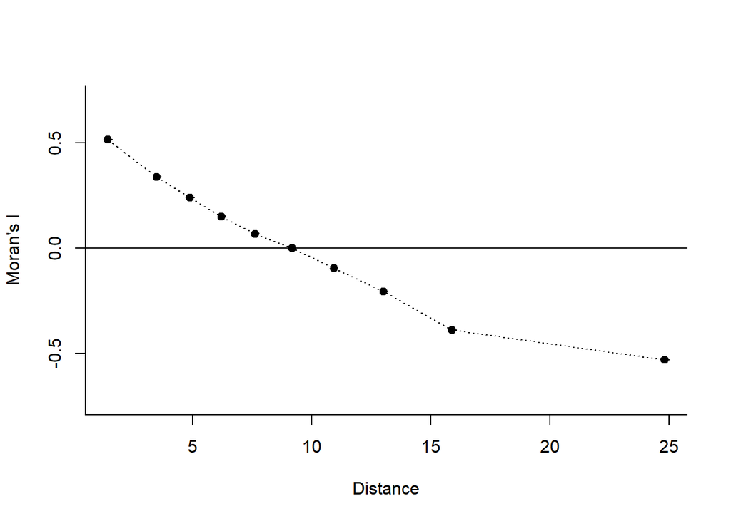

```
##           Observed Confidence_Interval_(95%) Expected_value      p_value
##  [1,]  0.514081096              0.0003421052  -4.161465e-05 0.0000000000
##  [2,]  0.336823645              0.0003399015  -4.161465e-05 0.0000000000
##  [3,]  0.239581162              0.0003404495  -4.161292e-05 0.0000000000
##  [4,]  0.150494205              0.0003409757  -4.161292e-05 0.0000000000
##  [5,]  0.068221850              0.0003422539  -4.161292e-05 0.0000000000
##  [6,] -0.000626706              0.0003443575  -4.161292e-05 0.0008678083
##  [7,] -0.094919932              0.0003444586  -4.161292e-05 0.0000000000
##  [8,] -0.205946381              0.0003430382  -4.161292e-05 0.0000000000
##  [9,] -0.389001092              0.0003379987  -4.161292e-05 0.0000000000
## [10,] -0.530845787              0.0002901109  -4.854605e-05 0.0000000000
##       Mean_Distance    Count
##  [1,]      1.426674 57756114
##  [2,]      3.493521 57755310
##  [3,]      4.878530 57776310
##  [4,]      6.212364 57722374
##  [5,]      7.612178 57750746
##  [6,]      9.164073 57751606
##  [7,]     10.924885 57751334
##  [8,]     13.019573 57747906
##  [9,]     15.899181 57752882
## [10,]     24.820132 57748410
```

```r
lets.correl(z.slp$z, dists, 10,
           equidistant = FALSE,
           plot = TRUE)
```

y con los datos del profe Juan?

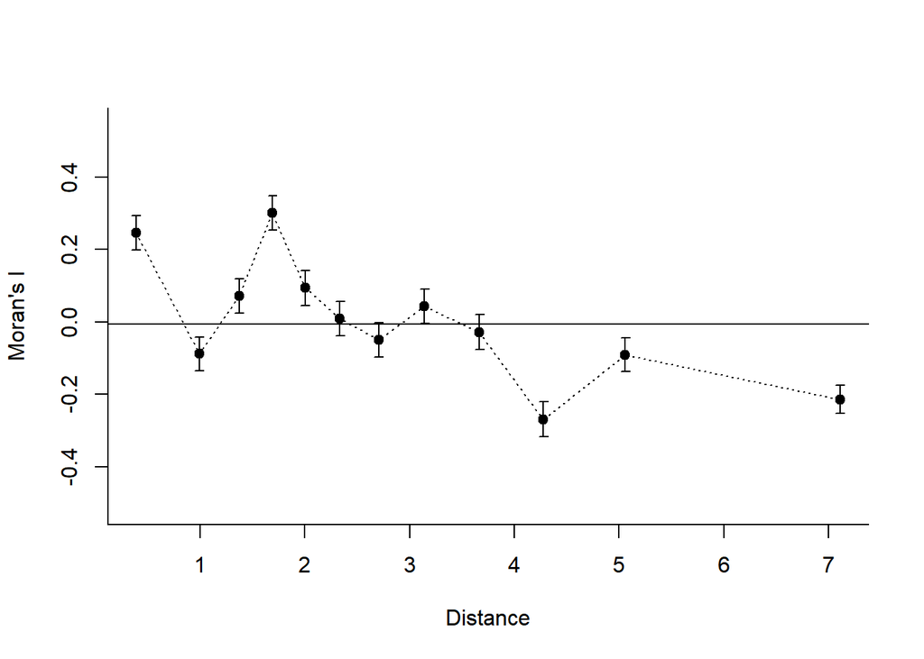

```
##           Observed Confidence_Interval_(95%) Expected_value      p_value
##  [1,]  0.246571816                0.04772204   -0.005291005 0.000000e+00
##  [2,] -0.088467686                0.04717248   -0.005464481 5.631795e-04
##  [3,]  0.071018150                0.04749406   -0.005319149 1.630962e-03
##  [4,]  0.301317544                0.04786739   -0.005291005 0.000000e+00
##  [5,]  0.094005513                0.04796801   -0.005291005 4.964086e-05
##  [6,]  0.008740447                0.04779738   -0.005291005 5.650345e-01
##  [7,] -0.049568644                0.04749525   -0.005347594 6.801874e-02
##  [8,]  0.043789005                0.04765571   -0.005291005 4.353100e-02
##  [9,] -0.028185105                0.04775376   -0.005347594 3.485836e-01
## [10,] -0.269301116                0.04777562   -0.005291005 2.453445e-27
## [11,] -0.091418677                0.04661154   -0.005524862 3.040714e-04
## [12,] -0.214043038                0.03899126   -0.007299270 2.681470e-25
##       Mean_Distance Count
##  [1,]     0.3899159  2994
##  [2,]     0.9926241  2992
##  [3,]     1.3727846  2992
##  [4,]     1.6901013  2992
##  [5,]     2.0021142  2994
##  [6,]     2.3353490  2992
##  [7,]     2.7072404  2992
##  [8,]     3.1416007  2992
##  [9,]     3.6665200  2992
## [10,]     4.2788402  2994
## [11,]     5.0591862  2992
## [12,]     7.1113351  2992
```

```r
lets.correl(datos_z$y, dists2, 12,
           equidistant = FALSE,
           plot = TRUE)
```

Los del profe juan si tienen barras de error… Por qué? Qué puede uno inferir ahi? Será que no hay autocorrelación espacial?